# Lab 11 - Hypothesis Testing

Carl Gladish

Nov 17, 2025

This lab contains some instructional material along with some questions. You are required to submit your answers in a Microsoft Word report produced by “knitting” an R Notebook to .docx format. Your Word file will contain *all* your R code *and* your written answers and charts.

Create your own R Markdown file (i.e., R notebook) called Lab_11_Notebook.Rmd.

**Due date: 11:59pm, two school days from today (weekend days count as half)**

## Lab Objectives

- Perform hypothesis tests about a population mean $\mu$
- Perform hypothesis tests comparing the means of two populations, $\mu_1$ and $\mu_2$
- Perform hypothesis test about $\mu_d$, the mean difference of two paired variables
- Perform hypothesis test about a population proportion $p$
- Perform hypothesis tests comparing the proportions for two populations, $p_1$ and $p_2$

## Testing a Hypothesis about a Population Mean $\mu$

First, load some required libraries and the data set `survey` (from the `MASS` library).

```r
library(MASS)
library(mosaic)
library(dplyr)
data(survey)
```

What population is represented in the data set `survey`? The help file says that `survey` comes from a set of statistics students at the University of Adelaide. We could make the reasonable assumption that the sample is representative of all students at University of Adelaide.

In Lab 10 we used the function `t.test` to construct confidence intervals for a population mean, $\mu$. This week we will use `t.test` to test a *hypothesis* about $\mu$, the mean value (of some variable) for all students at the University of Adelaide.

Let’s examine the variable **Age** in the `survey` data .

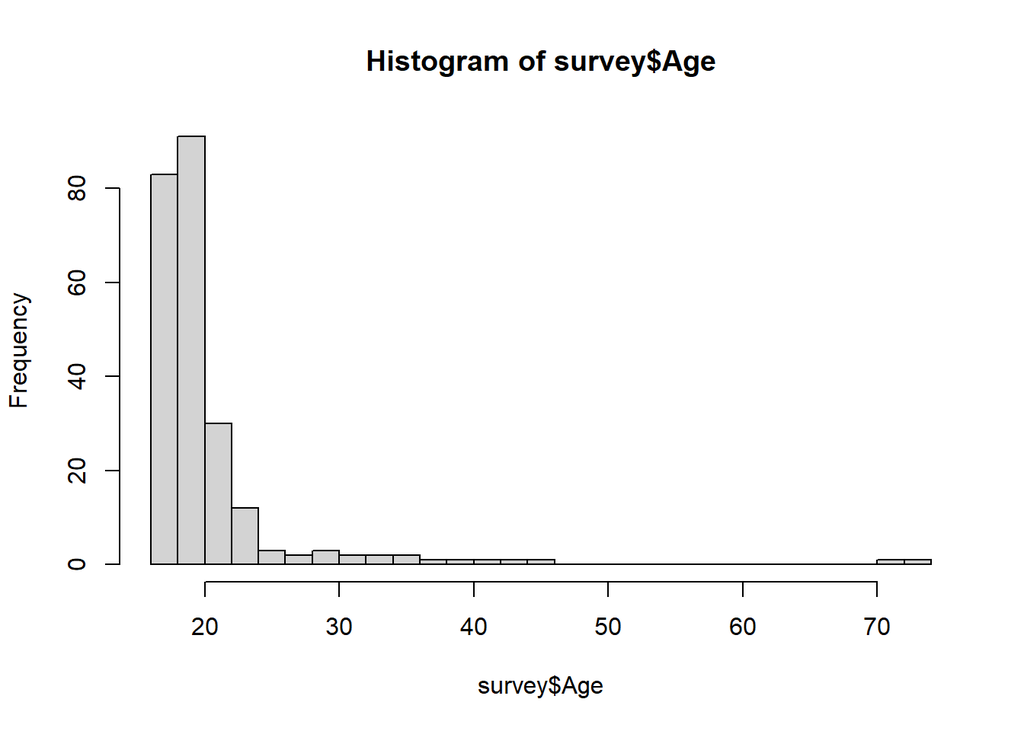

```r
hist(survey$Age, breaks=40)
```

**Age** is evidently a highly skewed variable. It even contains some outliers beyond the age of $70$. When we test hypotheses later, it will be critical that $n$ is quite large, since the variable **Age** is far from normally distributed.

What is the 95% confidence interval for the mean age $\mu$ of all students at the University of Adelaide?

```r
c.int <- t.test(survey$Age, conf.level=0.95)$conf.int
lim.lower <- round(c.int[1], 2)
lim.upper <- round(c.int[2], 2)
```

We obtain the interval: $(19.55, 21.2)$.

In other words, we have 95% confidence that the mean age of a student at the University of Adelaide is between 19.55 and 21.2 years.

### Hypothesis Testing Examples

**Example 1** Suppose we were testing the claim that the mean age of students at the University of Adelaide is $\mu=19.0$ years. Our hypotheses are:

$$H_0: \mu = 19$$
$$H_1: \mu \neq 19$$

We run the code

```r
t.test( survey$Age, mu=19, alternative="two.sided")
```

```
##
##  One Sample t-test
##
## data:  survey$Age
## t = 3.2683, df = 236, p-value = 0.001243
## alternative hypothesis: true mean is not equal to 19
## 95 percent confidence interval:
##  19.54600 21.20303
## sample estimates:
## mean of x
##  20.37451
```

The result includes the information that $p$-value $= 0.0012$. Since this is less than 0.05, we *reject* the null hypothesis.

Therefore, our conclusion is:

**There is strong enough evidence to reject the claim that the mean age of students at University of Adelaide is 19.0 years ($p$-value$=0.0012$).**

We could also say:

**The mean age of students at the University of Adelaide is not equal to 19.0 years ($p$-value$=0.0012$).**

Note that this conclusion agrees with the confidence interval we obtained earlier, which said that $\mu$ is in the interval $(19.55, 21.2)$ with 95% confidence.

**Example 2** Now suppose we were testing the claim that the mean age of students at the University of Adelaide is less than $21.0$ years. The appropriate hypotheses are:

$$H_0: \mu = 21$$
$$H_1: \mu < 21$$

We will need to perform a “left-tail” test. We run the code

```r
t.test( survey$Age, mu=21, alternative="less")
```

```
##
##  One Sample t-test
##
## data:  survey$Age
## t = -1.4873, df = 236, p-value = 0.06914
## alternative hypothesis: true mean is less than 21
## 95 percent confidence interval:
##      -Inf 21.06899
## sample estimates:
## mean of x
##  20.37451
```

The result includes the information that $p$-value $= 0.0691$. Since this is greater than 0.05, we *fail to reject* the null hypothesis.

Therefore, our conclusion is:

**There is not strong enough evidence to support the claim that the mean age of students at University of Adelaide is less than 21.0 years ($p$-value$=0.0691$).**

We could also say:

**Our evidence that the mean age is below 21.0 years is not statistically significant at the 5% level.**

Your conclusion should always mention either one or both of:

- the $p$-value
- the significance level, $\alpha$

### Question 1

You are going to investigate the variable **Pulse** (i.e., heart rate) in the `survey` data set. Note that the shape of this variable is approximately normal;

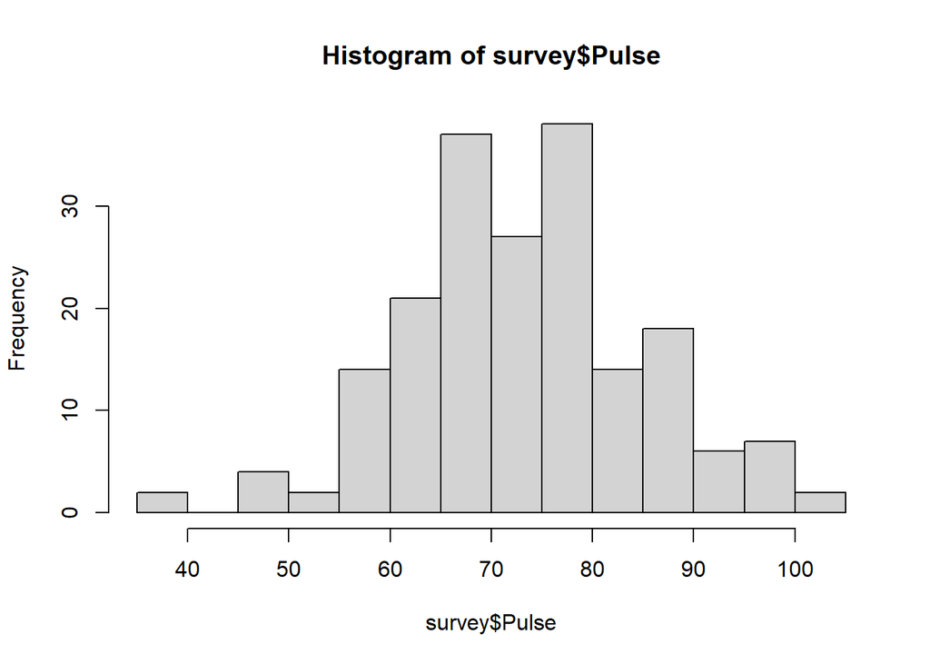

```r
n <- sum(! is.na( survey$Pulse ))
hist(survey$Pulse, breaks=15)
```

#### Q1a

Use `t.test` to test the claim that the mean **Pulse** for students at the University of Adelaide is 75.0 beats per minute. The relevant hypotheses are:

$$H_0: \mu = 75$$
$$H_1: \mu \neq 75$$
State your conclusion as a full sentence that:

- restates the original claim about the mean **Pulse**
- includes the $p$-value

#### Q1b

Use `t.test` to test the the claim that the mean **Pulse** for Female students is more than 75 beats per minute. You must:

- record your null and alternative hypothesis
- record whether you decide to *reject* $H_0$ or *fail to reject* $H_0$
- include a one-sentence conclusion that: restates the original claim *and* includes the $p$-value

### Question 2

#### Q2a

Write a function `runHypothesis` that takes arguments:

- `X.data` - the raw data for a numerical variable $X$
- `alpha` - the significance level to be used
- `var` - a descriptor/name of the variable $X$
- `unit` - the units applicable to the variable $X$
- `mu0` - the value of the population mean to be used in the null hypothesis
- `alt` – either “greater”, “less”, or “two.sided”

Your function should test the claim given by your inputs and return a sentence conclusion. For example:

```r
runHypothesis(survey$Age, 0.01, "student age", "years", 20, "greater")
```

```
## [1] "We do not have strong enough evidence to support the claim that the mean student age is greater than 20 years at the 1% significance level."
```

#### Q2b

Use your function `runHypothesis` to test the claim at the 10% significance level that the mean student **Pulse** rate is greater than 70 beats per minute.

#### Q2c

Use your function `runHypothesis` to test the claim at the 5% significance level that the mean student **Age** is less than 25 years.

### Question 3

The function `t.test` can also be used to *compare* two groups. For instance, if we make a side by side boxplot for Female and Male student **Height** we see that Female students appear to be shorter on average.

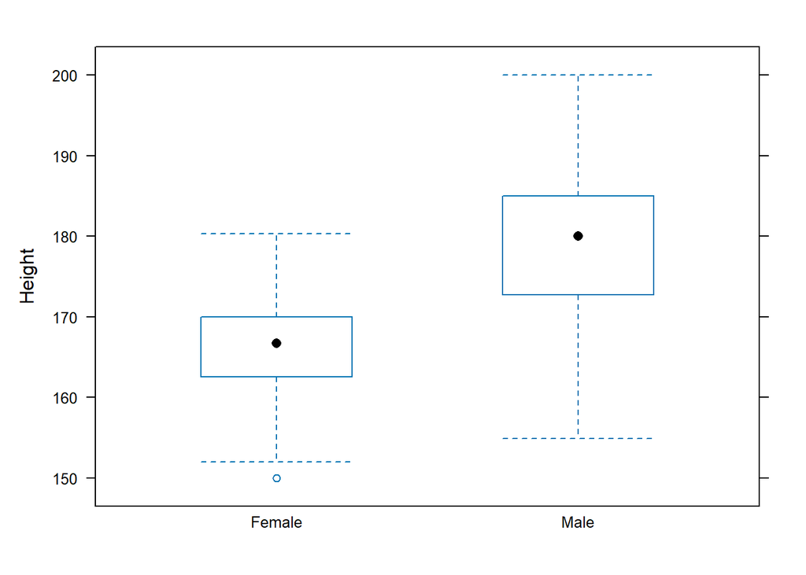

```r
bwplot(Height~Sex, data=survey)
```

It is important to be clear about which population is which. Here we assume:

- Female students are population 1
- Male students are population 2

The relevant hypotheses here are:

$$H_0: \mu_1 - \mu_2 = 0$$
$$H_1: \mu_1 - \mu_2 < 0$$

We can test the claim that female students are shorter than male students on average using:

```r
t.test( filter(survey, Sex=="Female")$Height,
        filter(survey, Sex=="Male")$Height, alternative="less")
```

```
##
##  Welch Two Sample t-test
##
## data:  filter(survey, Sex == "Female")$Height and filter(survey, Sex == "Male")$Height
## t = -12.924, df = 192.7, p-value < 2.2e-16
## alternative hypothesis: true difference in means is less than 0
## 95 percent confidence interval:
##       -Inf -11.45907
## sample estimates:
## mean of x mean of y
##  165.6867  178.8260
```

The results give an extremely small $p$-value of $2.2\times 10^{-16}$. So we *reject* $H_0$ and conclude that:

The mean height of female students is less than the mean height of male students at the University of Adelaide ($p$-value$=0+$).

#### Q3a

Test the claim that the mean **Pulse** rates for male and female students at the University of Adelaide are equal. Include:

- The hypotheses $H_0$ and $H_1$
- Your decision (*reject* or *fail to reject* $H_0$)
- A one-sentence conclusion that restates the original claim and includes the $p$-value.

#### Q3b

Test the claim that female students are older on average than male students at the University of Adelaide. Include:

- The hypotheses $H_0$ and $H_1$
- Your decision (*reject* or *fail to reject* $H_0$)
- A one-sentence conclusion that restates the original claim and includes the $p$-value.

### Question 4

In the next question, you are going to compare **Wr.Hnd** (the size of a student’s *writing* hand) and **NW.Hnd** (the side of a student’s *non-writing* hand). These are what we call “paired” samples, since the two numbers come from one unit (one person, in this case). The two samples (writing and non-writing) are *dependent*.

Read the helpfile for `t.test` to find out how to handle a comparison of two *dependent* samples.

Then test the claim that the span of students writing hand differs from the span of their non-writing hands. Your hypotheses are:

$$H_0: \mu_d = 0$$
$$H_1: \mu_d \neq 0$$

Include a one-sentence conclusion.

## Testing a Hypothesis about a Population Proportion $p$

When working with categorical data, we typically test hypotheses related to $p$, the population proportion for some category.

**Example (Handedness)** Test the claim that more than two-thirds of the students are University of Adelaide are right-handed.

$$H_0: p = \frac{2}{3}$$
$$H_1: p > \frac{2}{3}$$

```r
X.vals <- survey$W.Hnd[!is.na( survey$W.Hnd )]
n <- length(X.vals)
k <- sum(X.vals == "Right")
prop.test( k, n, p = 2/3,
           alternative="greater", conf.level=0.95 )
```

```
##
##  1-sample proportions test with continuity correction
##
## data:  k out of n
## X-squared = 69.026, df = 1, p-value < 2.2e-16
## alternative hypothesis: true p is greater than 0.6666667
## 95 percent confidence interval:
##  0.8878199 1.0000000
## sample estimates:
##         p
## 0.9237288
```

Decision: the $p$-value is extremely small, so we reject $H_0$

Conclusion: More than two-thirds of students at the University of Adelaide are right-handed ($p$-value$=2.2\times 10^{-16}$).

### Question 5

Use `prop.test` to answer each of the following. For all cases, use $\alpha=0.05$. For each problem, record:

- the appropriate hypotheses
- your decision (*reject* or *fail to reject* $H_0$)
- a one-sentence conclusion that restates the original claim and includes the $p$-value

#### Q5a

Test the claim that the proportion of left-handedness among female students at the University of Adelaide is at most 10%.

#### Q5b

Test the claim that, among right-handed students, the proportion who exercise *frequently* is equal to 50%.

#### Q5c

Test the claim that students at University of Adelaide who never smoke are equally likely to be frequent exercisers as students who smoke heavily.